# ch8

## [Welcome Back : Check-In Here](https://docs.google.com/forms/d/e/1FAIpQLSdyVnc80GrkTtGyaESOJJjjlAUHAUfpgMeiVkpZRo2JhKEbgQ/viewform)

```r
library(car)
library(gplots)
mod <- lm(salary ~ sex, data = Salaries)
summary(mod)
```

```
Call:
lm(formula = salary ~ sex, data = Salaries)

Residuals:
   Min     1Q Median     3Q    Max
-57290 -23502  -6828  19710 116455

Coefficients:
            Estimate Std. Error t value Pr(>|t|)
(Intercept)   101002       4809  21.001  < 2e-16 ***
sexMale        14088       5065   2.782  0.00567 **
---
Signif. codes:  0 '***' 0.001 '**' 0.01 '*' 0.05 '.' 0.1 ' ' 1

Residual standard error: 30030 on 395 degrees of freedom
Multiple R-squared:  0.01921,   Adjusted R-squared:  0.01673
F-statistic: 7.738 on 1 and 395 DF,  p-value: 0.005667
```

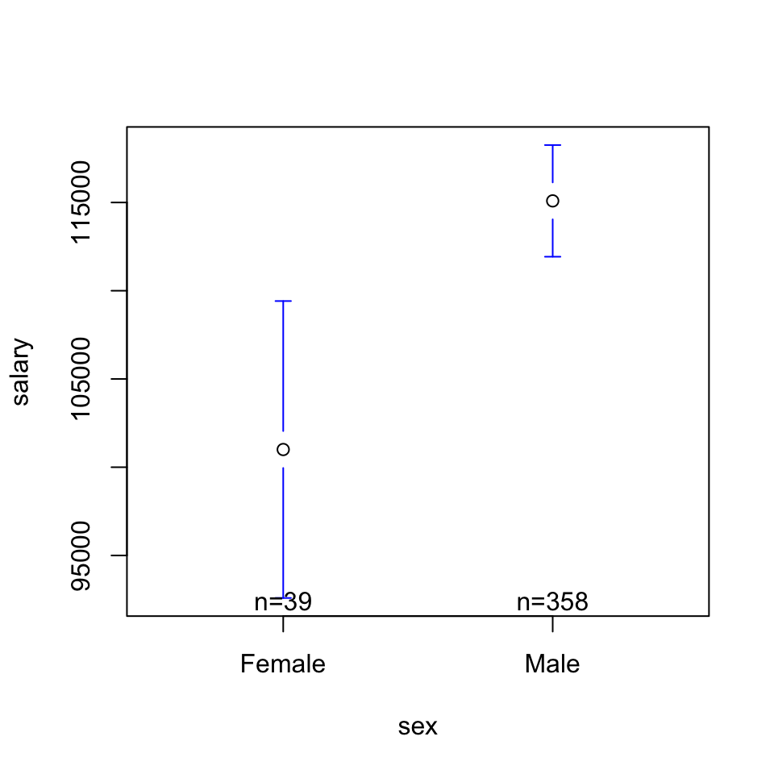

```r
plotmeans(salary ~ sex, data = Salaries, connect = F)
```

## More Examples

- **ice-breaker :** dream life (utopia)?
- **the stats & who cares :** what’s the slope, significance, R^2; how would you use this knowledge??
- model 1
- model 2

```r
mod1 <- lm(salary ~ yrs.service, data = Salaries)
summary(mod1)
```

```
Call:
lm(formula = salary ~ yrs.service, data = Salaries)

Residuals:
   Min     1Q Median     3Q    Max
-81933 -20511  -3776  16417 101947

Coefficients:
            Estimate Std. Error t value Pr(>|t|)
(Intercept)  99974.7     2416.6   41.37  < 2e-16 ***
yrs.service    779.6      110.4    7.06 7.53e-12 ***
---
Signif. codes:  0 '***' 0.001 '**' 0.01 '*' 0.05 '.' 0.1 ' ' 1

Residual standard error: 28580 on 395 degrees of freedom
Multiple R-squared:  0.1121,    Adjusted R-squared:  0.1098
F-statistic: 49.85 on 1 and 395 DF,  p-value: 7.529e-12
```

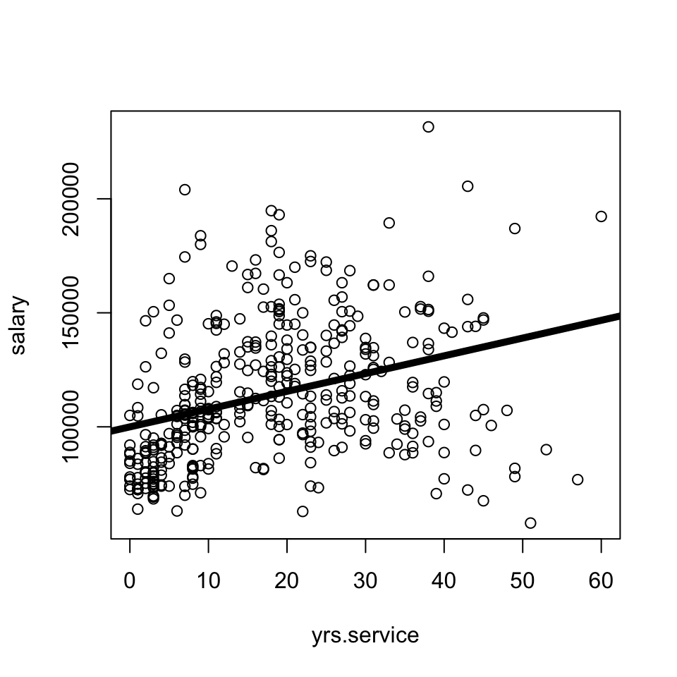

```r
plot(salary ~ yrs.service, data = Salaries)
abline(mod1, lwd = 5)
```

```r
mod2 <- lm(yrs.service ~ sex, data = Salaries)
summary(mod2)
```

```
Call:
lm(formula = yrs.service ~ sex, data = Salaries)

Residuals:
    Min      1Q  Median      3Q     Max
-18.274 -10.564  -0.564   8.726  41.726

Coefficients:
            Estimate Std. Error t value Pr(>|t|)
(Intercept)    11.56       2.06   5.612 3.76e-08 ***
sexMale         6.71       2.17   3.092  0.00213 **
---
Signif. codes:  0 '***' 0.001 '**' 0.01 '*' 0.05 '.' 0.1 ' ' 1

Residual standard error: 12.87 on 395 degrees of freedom
Multiple R-squared:  0.02364,   Adjusted R-squared:  0.02116
F-statistic: 9.562 on 1 and 395 DF,  p-value: 0.002127
```

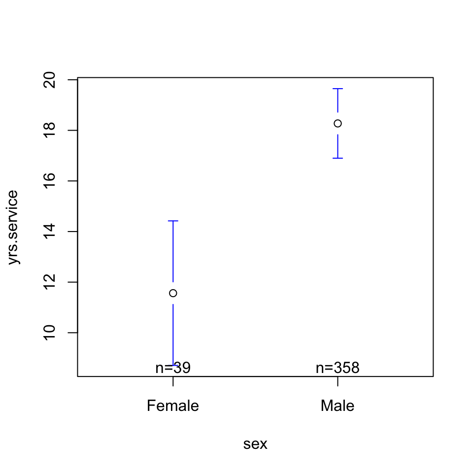

```r
plotmeans(yrs.service ~ sex, data = Salaries, connect = F)
```

## NHST Review.

- Slope
- Standard Error
- Significance is Not…
- Significance is Not
- Significance Is…
- …Confusing.
- Other Questions?
- Direction & Strength of a Relationship
- Hard to evaluate strength across models if the units differ too.

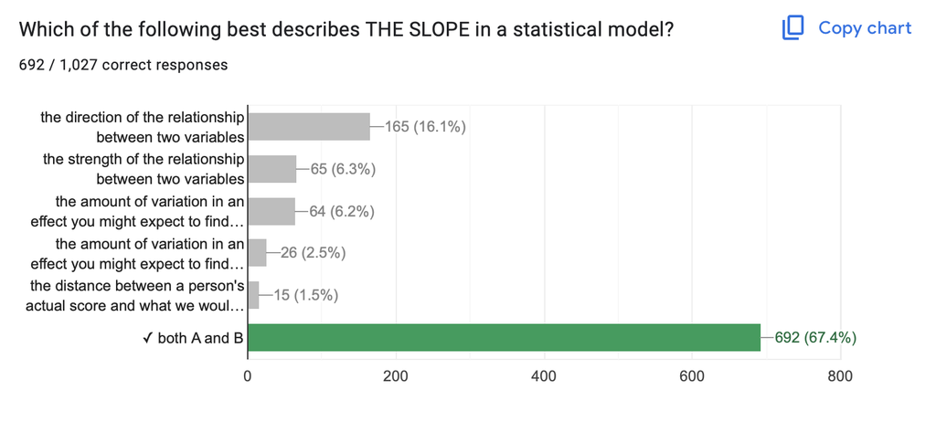

- The amount of variation in an effect you might expect to find due to chance if the null hypothesis were “true”.

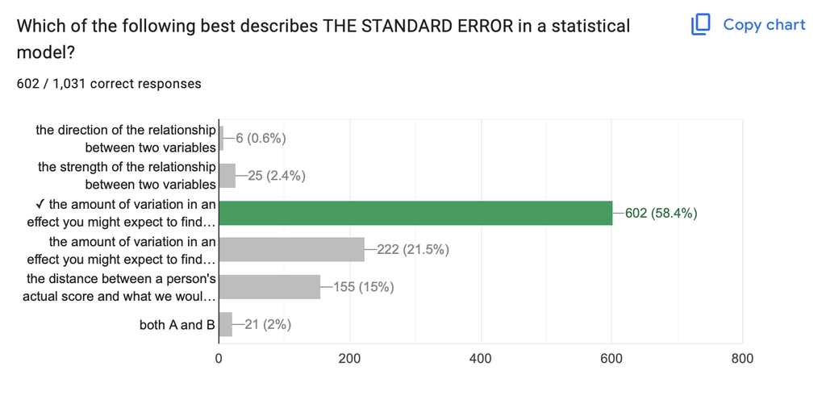

- …about slope! Large slope & sampling error = NOT SIGNIFICANT

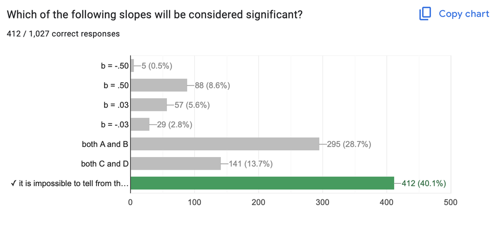

- **…about size :** you can be VERY confident that a small effect is not due to sampling error.
- **…about importance :** why does the effect matter?
- **…about truth :** our estimates of sampling error are all made up.

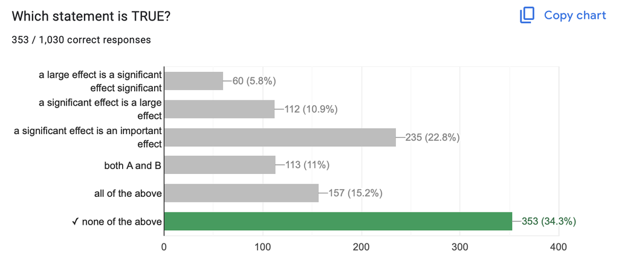

**A p-value of .03 means…there is a 3% chance that this slope (or a stronger slope) would be found due to chance if the true correlation was zero.**

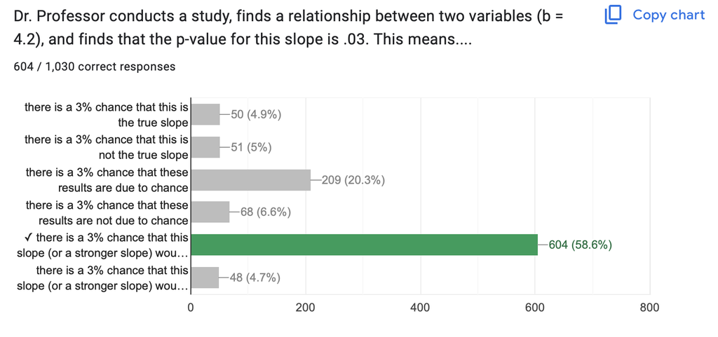

Haller, H., & Krauss, S. (2002). [Misinterpretations of significance: A problem students share with their teachers](https://www.metheval.uni-jena.de/lehre/0405-ws/evaluationuebung/haller.pdf). Methods of Psychological Research, 7(1), 1-20.

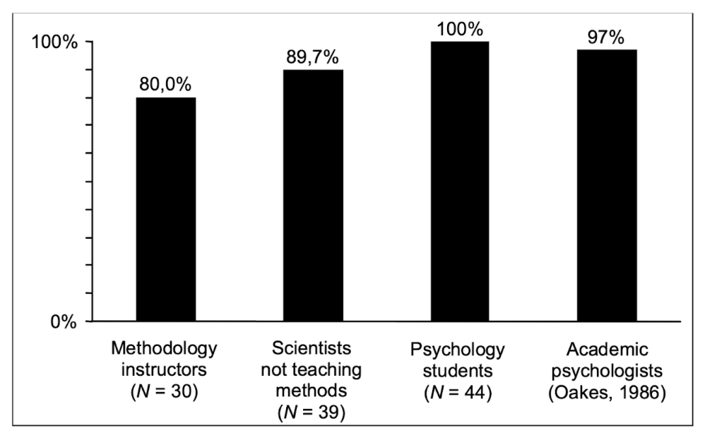

[figure not shown]

### NEXT TIME

1. sex is related to salary
2. years of service is related to salary.
3. sex and years of service are related to each other……

```r
mod4 <- lm(salary ~ sex + yrs.service, data = Salaries)
summary(mod4)
```

```
Call:
lm(formula = salary ~ sex + yrs.service, data = Salaries)

Residuals:
   Min     1Q Median     3Q    Max
-81757 -20614  -3376  16779 101707

Coefficients:
            Estimate Std. Error t value Pr(>|t|)
(Intercept)  92356.9     4740.2  19.484  < 2e-16 ***
sexMale       9071.8     4861.6   1.866   0.0628 .
yrs.service    747.6      111.4   6.711 6.74e-11 ***
---
Signif. codes:  0 '***' 0.001 '**' 0.01 '*' 0.05 '.' 0.1 ' ' 1

Residual standard error: 28490 on 394 degrees of freedom
Multiple R-squared:  0.1198,    Adjusted R-squared:  0.1154
F-statistic: 26.82 on 2 and 394 DF,  p-value: 1.201e-11
```

## PART 2 : Project Time

### [Final Project Description and Rubric](https://docs.google.com/document/d/1ScvG86PiyyqHO7Ob5bki04XGzCwLodQ4h57n9Jq5DYI/edit?usp=sharing)

- How does this make you feel?
- Questions / areas of concern?

### Looking Over Datasets

1. Which dataset did you choose, and what interests you about this dataset?
2. Look over the codebook - identify at least two different variables that you are interested in, and explain why you are interested in each one.
3. Download the data to your computer, and load the data into R. Make sure the data loaded correctly. Graph ONE of the variables that you are interested in; what do you notice about how people differ on this variable?